# Using the Children Weight Change Model

Rodrigo Zepeda Tello & Dalia Camacho García Formentí

2018-03-14

# Usage in R

The main inputs for the body weight change model are:

| Input | Meaning | Optional | Default |
| --- | --- | --- | --- |
| `age` | Age (yrs) | No | - |
| `sex` | Either `'male'` or `'female'` | No | - |

As an example consider a `7` year old `'female'`:

```r
female_model1 <- child_weight(age = 7, sex = "female")
```

Furthermore, the model allows the user to input Fat and Fat Free Mass composition of the body:

| Input | Meaning | Optional | Default |
| --- | --- | --- | --- |
| `FM` | Fat Mass (kg) | Yes | Model estimate |
| `FFM` | Fat Free Mass (kg) | Yes | Model estimate |

For example, our female might have `19.9` kg of Fat Mass and `5.74` kg of Fat Free Mass:

```r
female_model2 <- child_weight(age = 7, sex = "female", FM = 19.9, FFM = 5.74)
```

Energy intake can also be inputed as a vector of daily energy consumption:

| Input | Meaning | Optional | Default |
| --- | --- | --- | --- |
| `EI` | Energy Intake per day | Yes | Model estimate |

```r
female_model3 <- child_weight(age = 7, sex = "female", FM = 19.9, FFM = 5.74,
                              EI = seq(1600, 1750, length.out = 365))
```

Other (optional) inputs include:

| Input | Meaning | Optional | Default |
| --- | --- | --- | --- |
| `days` | Number of days to run de model | Yes | $365$ |
| `checkValues` | Boolean indicating whether the model should check parameters make sense | Yes | `TRUE` |

All inputs used in the model are:

| Input | Meaning | Optional | Default |
| --- | --- | --- | --- |
| `age` | Age (yrs) | No | - |
| `sex` | Either `'male'` or `'female'` | No | - |
| `FM` | Fat Mass (kg) | Yes | Model estimate |
| `FFM` | Fat Free Mass (kg) | Yes | Model estimate |
| `EI` | Energy Intake per day | Yes | Model estimate |
| `days` | Time period (days) to run the model | Yes | $365$ |
| `checkValues` | Check for internal consistency | Yes | `TRUE` |

```r
#Database information
ages    <- c(8, 10, 7, 7, 12)
sexes   <- c("male", "female", "female", "male", "male")

#Returns a weight change matrix and other matrices
database_model <- child_weight(ages, sexes)
```

## Plots

Result plots can be obtained by `model_plot` function:

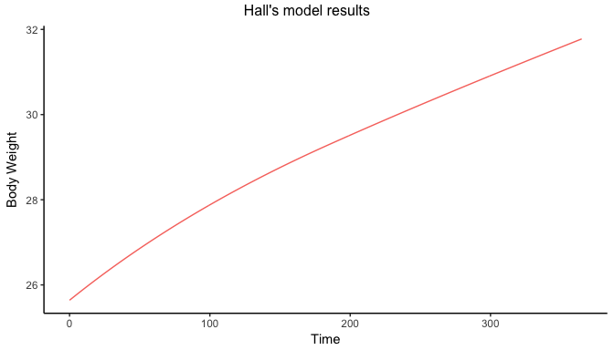

```r
model_plot(female_model2, "Body_Weight")
```

Plotting options include `"Body_Weight"`, `Fat_Mass`, `Lean_Mass`, `Glycogen`, `Extracellular_Fluid` and `Adaptive_Thermogenesis`. Several can be chosen at the same time:

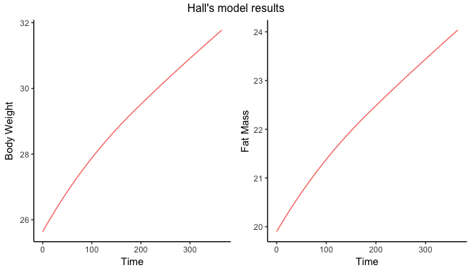

```r
model_plot(female_model2, c("Body_Weight", "Fat_Mass"))
```

Variables can also be plotted against age:

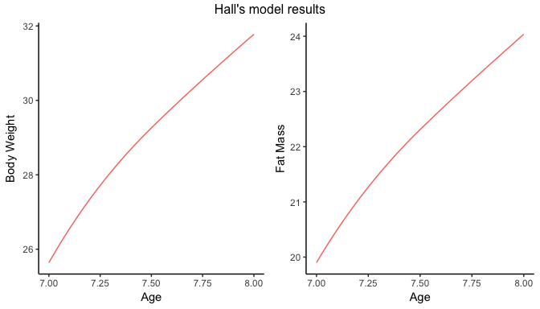

```r
model_plot(female_model2, c("Body_Weight", "Fat_Mass"), timevar = "Age")
```

## Energy

Energy intake is usually not continuously measured but measured at different and distant points in time (say 1 year apart). The function `energy_build` allows the user to interpolate different energy models between the interpolation points. As an example consider an individual that initially consumed `1600` kcals, by day `365` consumed in `1750` kcals and by day `730` had increased his consumption to `1820` kcals. The `energy_build` function interpolates those values via a Brownian Bridge:

```r
EIbrownian <- energy_build(c(1600, 1750, 1820), c(0, 365, 730))
```

The interpolation looks like this:

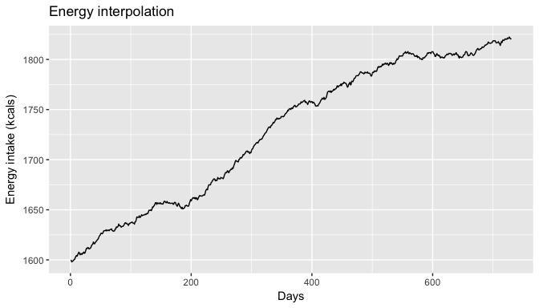

```r
ggplot() + geom_line(aes(x = 1:730, y = EI), data = data.frame(EI = EIbrownian)) +
  xlab("Days") + ylab("Energy intake (kcals)") + ggtitle("Energy interpolation")
```

Such energy change matrix can be directly inputed in the model:

```r
model_brownian <- child_weight(10, "male", EI = EIbrownian, days = 730)
```

Other interpolation modes include `Linear`, `Exponential`, `Stepwise_R` (right stepwise), `Stepwise_L` (left stepwise), and `Logarithmic`:

```r
EIlinear      <- energy_build(c(1600, 1750, 1820), c(0, 365, 730), "Linear")
EIexponential <- energy_build(c(1600, 1750, 1820), c(0, 365, 730), "Exponential")
EIstepwise_r  <- energy_build(c(1600, 1750, 1820), c(0, 365, 730), "Stepwise_R")
EIstepwise_l  <- energy_build(c(1600, 1750, 1820), c(0, 365, 730), "Stepwise_L")
EIlogarithmic <- energy_build(c(1600, 1750, 1820), c(0, 365, 730), "Logarithmic")
```

Which look like this:

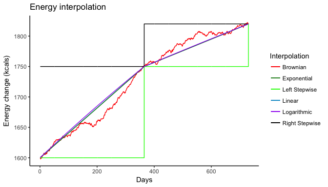

```r
ggplot() +
  geom_line(aes(x = 1:730, y = EI, color = "Brownian"), data = data.frame(EI = EIbrownian)) +
  geom_line(aes(x = 1:730, y = EI, color = "Linear"), data = data.frame(EI = EIlinear)) +
  geom_line(aes(x = 1:730, y = EI, color = "Exponential"), data = data.frame(EI = EIexponential)) +
  geom_step(aes(x = 1:730, y = EI, color = "Right Stepwise"), data = data.frame(EI = EIstepwise_r)) +
  geom_step(aes(x = 1:730, y = EI, color = "Left Stepwise"), data = data.frame(EI = EIstepwise_l)) +
  geom_line(aes(x = 1:730, y = EI, color = "Logarithmic"), data = data.frame(EI = EIlogarithmic)) +
  xlab("Days") + ylab("Energy change (kcals)") + ggtitle("Energy interpolation") +
  theme_classic() +
  scale_color_manual("Interpolation",
                     values = c("Brownian" = "red", "Linear" = "deepskyblue3",
                                "Exponential" = "forestgreen", "Logarithmic" = "purple",
                                "Right Stepwise" = "black", "Left Stepwise" = "green"))
```

These models result in different weight changes:

```r
model_linear      <- child_weight(10, "male", EI = EIlinear, days = 730)
model_exponential <- child_weight(10, "male", EI = EIexponential, days = 730)
model_logarithmic <- child_weight(10, "male", EI = EIlogarithmic, days = 730)
model_stepwise_r  <- child_weight(10, "male", EI = EIstepwise_r, days = 730)
model_stepwise_l  <- child_weight(10, "male", EI = EIstepwise_l, days = 730)
```

Which look as follows:

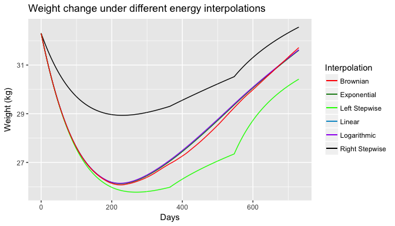

## Estimating weight change of a database

Vector data can also be used in the model to calculate weight change for several individuals at a time (which is quite faster than doing them individually). As an example consider the following dataset:

```r
#Database information
mydata <- data.frame(
  id = 1:5,
  age = c(8, 10, 7, 7, 12),
  sex = c("male", "female", "female", "male", "male"),
  energy = runif(5, 1500, 2000),
  prob = c(0.1, 0.2, 0.2, 0.05, 0.45))

#Get energy change with energy build function
eichange      <- energy_build(cbind(runif(5, 1500, 2000), mydata$energy), c(0, 365))

#Returns a weight change matrix and other matrices
database_model <- child_weight(mydata$age, mydata$sex, EI = t(eichange))
```

Plots can also be obtained for the population with the same command `model_plot`:

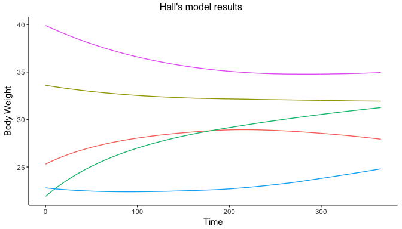

```r
model_plot(database_model, "Body_Weight")
```

Summary measures can be obtained via `model_mean` which quantifies mean for `'Body_Weight'`, `'Fat_Free_Mass'`, and `'Fat_Mass'`:

```r
model_mean(database_model, "Body_Weight")
```

```
##   time    variable group     mean  SE_mean
## 1    0 Body_Weight     1 28.70000 3.478937
## 2   15 Body_Weight     1 28.85780 3.234291
## 3   30 Body_Weight     1 28.97969 3.030974
## 4   45 Body_Weight     1 29.07562 2.860357
## 5   60 Body_Weight     1 29.15330 2.716478
## 6   76 Body_Weight     1 29.22210 2.587292
```

Mean is only estimated for some points in time, to estimate mean for the whole period, consider changing the `days` vector variable:

```r
model_mean(database_model, "Body_Weight", days = 1:365)
```

```
##   time    variable group     mean  SE_mean
## 1    1 Body_Weight     1 28.71192 3.461132
## 2    2 Body_Weight     1 28.72361 3.443559
## 3    3 Body_Weight     1 28.73510 3.426208
## 4    4 Body_Weight     1 28.74638 3.409084
## 5    5 Body_Weight     1 28.75741 3.392185
## 6    6 Body_Weight     1 28.76825 3.375492
```

Mean can also be grouped by a variable (say, `sex`):

```r
model_mean(database_model, "Body_Weight", days = 1:365, group = mydata$sex)
```

```
##   time    variable  group     mean  SE_mean
## 1    1 Body_Weight female 27.78366 4.585756
## 2    1 Body_Weight   male 29.33076 4.850875
## 3    2 Body_Weight female 27.81685 4.547153
## 4    2 Body_Weight   male 29.32811 4.834140
## 5    3 Body_Weight female 27.84962 4.508999
## 6    3 Body_Weight   male 29.32543 4.817574
```

Finally, `model_mean` can also be used to estimate `survey` means using the `svydesign` from the `survey` package:

```r
require("survey")
design <- svydesign(ids = ~id, probs = ~prob, data = mydata)
model_mean(database_model, group = mydata$sex, design = design)
```

```
##   time      variable  group      mean   SE_mean
## 1    0           Age female  8.500000 1.1858541
## 2    0           Age   male  7.655172 0.5772886
## 3    0 Fat_Free_Mass female 22.300000 3.2413346
## 4    0 Fat_Free_Mass   male 21.468966 1.4274394
## 5    0      Fat_Mass female  5.450000 1.3834965
## 6    0      Fat_Mass   male  3.286207 0.3756837
```

Additional information on the model for adults and other package functions can be obtained in the other package’s Vignettes

```r
browseVignettes("bw")
```